# predict_heart_disease

ITM 390-Machine Learning: Logistic Regression Implementation

Topic: Implement Logistic Regression based on Paper

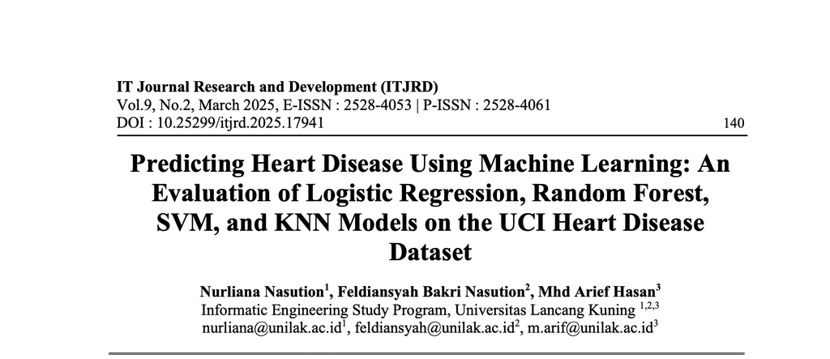

## Outline

# 1. Data Gathering(Loading dataset and visualization data)

## 1.1 Loading Dataset

```python
import pandas as pd

df = pd.read_csv('heart_disease_uci.csv')
```

[output not shown]

## 1.2 Data Visualization

To understand the "Heart Disease UCI" dataset more deeply, data visualization is crucial. Through visualization helps identify

- Patterns
- Trends
- Anomalies that are not visible in tabular data form
- Distribution of features
- The relationships between features
- And the influence of certain features on the target variable (heart disease).

### 1.2.1 Satistical Summary

Using "df/describe()" to get a statistical summary of the dataset.

```python
df.describe()
```

|  | id | age | trestbps | chol | thalch | oldpeak | ca | num |
| --- | --- | --- | --- | --- | --- | --- | --- | --- |
| count | 920.000000 | 920.000000 | 861.000000 | 890.000000 | 865.000000 | 858.000000 | 309.000000 | 920.000000 |
| mean | 460.500000 | 53.510870 | 132.132404 | 199.130337 | 137.545665 | 0.878788 | 0.676375 | 0.995652 |
| std | 265.725422 | 9.424685 | 19.066070 | 110.780810 | 25.926276 | 1.091226 | 0.935653 | 1.142693 |
| min | 1.000000 | 28.000000 | 0.000000 | 0.000000 | 60.000000 | -2.600000 | 0.000000 | 0.000000 |
| 25% | 230.750000 | 47.000000 | 120.000000 | 175.000000 | 120.000000 | 0.000000 | 0.000000 | 0.000000 |
| 50% | 460.500000 | 54.000000 | 130.000000 | 223.000000 | 140.000000 | 0.500000 | 0.000000 | 1.000000 |
| 75% | 690.250000 | 60.000000 | 140.000000 | 268.000000 | 157.000000 | 1.500000 | 1.000000 | 2.000000 |
| max | 920.000000 | 77.000000 | 200.000000 | 603.000000 | 202.000000 | 6.200000 | 3.000000 | 4.000000 |

### 1.2.2 Data Info

Using "df.info()" to get a concise summary of the DataFrame, including the data types and non-null values.

```python
df.info()
```

```
<class 'pandas.core.frame.DataFrame'>
RangeIndex: 920 entries, 0 to 919
Data columns (total 16 columns):
 #   Column    Non-Null Count  Dtype
---  ------    --------------  -----
 0   id        920 non-null    int64
 1   age       920 non-null    int64
 2   sex       920 non-null    object
 3   dataset   920 non-null    object
 4   cp        920 non-null    object
 5   trestbps  861 non-null    float64
 6   chol      890 non-null    float64
 7   fbs       830 non-null    object
 8   restecg   918 non-null    object
 9   thalch    865 non-null    float64
 10  exang     865 non-null    object
 11  oldpeak   858 non-null    float64
 12  slope     611 non-null    object
 13  ca        309 non-null    float64
 14  thal      434 non-null    object
 15  num       920 non-null    int64
dtypes: float64(5), int64(3), object(8)
memory usage: 115.1+ KB
```

### 1.2.3 Visualizing Data with Graphs

#### Age Distribution:

**👉 Click to view code**

```
import matplotlib.pyplot as plt
plt.hist(df['age'], bins=10, color='blue', alpha=0.7)
plt.title('Age Distribution')
plt.xlabel('Age')
plt.ylabel('Frequency')
plt.show()
```

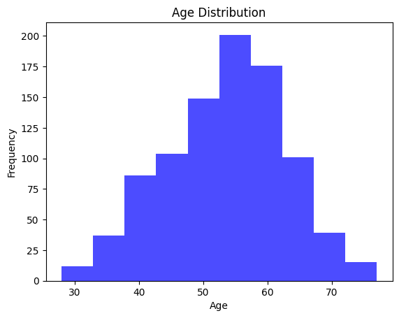

```python
import matplotlib.pyplot as plt
plt.hist(df['age'], bins=10, color='blue', alpha=0.7)
plt.title('Age Distribution')
plt.xlabel('Age')
plt.ylabel('Frequency')
plt.show()
```

#### Sex Distribution:

A bar chart showing the number of male and female patients. It helps see the difference in the prevalence of heart disease between genders.

**👉 Click to view code**

```
import matplotlib.pyplot as plt
import numpy as np

# Example data
categories = ["Total", "Diseased"]
# Female counts
female = [(df["sex"] == "Female").sum(),((df["sex"] == "Female") & (df["num"] > 0)).sum()] # [total female, disease females]

# Male counts
male = [(df["sex"] == "Male").sum(),((df["sex"] == "Male") & (df["num"] > 0)).sum()]    # [total male,diseased males]



x = np.arange(len(categories))  # positions
width = 0.35                    # bar width

fig, ax = plt.subplots(figsize=(6,4))

# Plot bars

ax.bar(x + width/2, male, width, label="Male")
ax.bar(x - width/2, female, width, label="Female")

# Labels & title
ax.set_ylabel("Number of People")
ax.set_title("Gender Distribution and Disease Count")
ax.set_xticks(x)
ax.set_xticklabels(categories)
ax.legend()

# Show values on top
for bars in ax.containers:
    ax.bar_label(bars, padding=3)

plt.show()
```

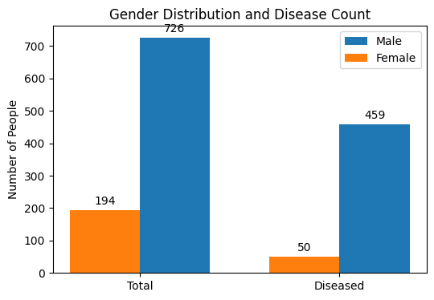

```python
import matplotlib.pyplot as plt
import numpy as np

# Example data
categories = ["Total", "Diseased"]
# Female counts
female = [(df["sex"] == "Female").sum(),((df["sex"] == "Female") & (df["num"] > 0)).sum()] # [total female, disease females]

# Male counts
male = [(df["sex"] == "Male").sum(),((df["sex"] == "Male") & (df["num"] > 0)).sum()]    # [total male,diseased males]

x = np.arange(len(categories))  # positions
width = 0.35                    # bar width

fig, ax = plt.subplots(figsize=(6,4))

# Plot bars

ax.bar(x + width/2, male, width, label="Male")
ax.bar(x - width/2, female, width, label="Female")

# Labels & title
ax.set_ylabel("Number of People")
ax.set_title("Gender Distribution and Disease Count")
ax.set_xticks(x)
ax.set_xticklabels(categories)
ax.legend()

# Show values on top
for bars in ax.containers:
    ax.bar_label(bars, padding=3)

plt.show()
```

#### Chest Pain Type Distribution:

**Click to review code**

```
import matplotlib.pyplot as plt
import numpy as np

# Example data
categories = ["TA", "ATA", "NAP", "ASY"]
# Female counts
female = [((df["sex"] == "Female") & (df["cp"]== "typical angina")).sum(),
          ((df["sex"] == "Female") & (df["cp"]== "atypical angina")).sum(),
          ((df["sex"] == "Female") & (df["cp"]== "non-anginal")).sum(),
          ((df["sex"] == "Female") & (df["cp"]== "asymptomatic")).sum()] # [total female, disease females]

# Male counts
male = [((df["sex"] == "Male") & (df["cp"]== "typical angina")).sum(),
          ((df["sex"] == "Male") & (df["cp"]== "atypical angina")).sum(),
          ((df["sex"] == "Male") & (df["cp"]== "non-anginal")).sum(),
          ((df["sex"] == "Male") & (df["cp"]== "asymptomatic")).sum()]    # [total male,diseased males]



x = np.arange(len(categories))  # positions
width = 0.35                    # bar width

fig, ax = plt.subplots(figsize=(6,4))

# Plot bars
ax.bar(x + width/2, male, width, label="Male")
ax.bar(x - width/2, female, width, label="Female")


# Labels & title
ax.set_ylabel("Number of People")
ax.set_title("Gender Distribution and Disease Count")
ax.set_xticks(x)
ax.set_xticklabels(categories)
ax.legend()

# Show values on top
for bars in ax.containers:
    ax.bar_label(bars, padding=3)

plt.show()
```

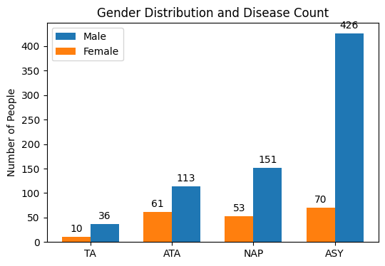

```python
import matplotlib.pyplot as plt
import numpy as np

# Example data
categories = ["TA", "ATA", "NAP", "ASY"]
# Female counts
female = [((df["sex"] == "Female") & (df["cp"]== "typical angina")).sum(),
          ((df["sex"] == "Female") & (df["cp"]== "atypical angina")).sum(),
          ((df["sex"] == "Female") & (df["cp"]== "non-anginal")).sum(),
          ((df["sex"] == "Female") & (df["cp"]== "asymptomatic")).sum()] # [total female, disease females]

# Male counts
male = [((df["sex"] == "Male") & (df["cp"]== "typical angina")).sum(),
          ((df["sex"] == "Male") & (df["cp"]== "atypical angina")).sum(),
          ((df["sex"] == "Male") & (df["cp"]== "non-anginal")).sum(),
          ((df["sex"] == "Male") & (df["cp"]== "asymptomatic")).sum()]    # [total male,diseased males]



x = np.arange(len(categories))  # positions
width = 0.35                    # bar width

fig, ax = plt.subplots(figsize=(6,4))

# Plot bars
ax.bar(x + width/2, male, width, label="Male")
ax.bar(x - width/2, female, width, label="Female")


# Labels & title
ax.set_ylabel("Number of People")
ax.set_title("Gender Distribution and Disease Count")
ax.set_xticks(x)
ax.set_xticklabels(categories)
ax.legend()

# Show values on top
for bars in ax.containers:
    ax.bar_label(bars, padding=3)

plt.show()
```

#### Cholesterol Distribution:

A histogram showing the distribution of cholesterol levels in patients' blood. It helps identify cholesterol levels at high risk for heart disease.

**👉 Click to view codeClick to view code**

```
plt.hist(df['chol'], bins=25, color='blue', alpha= 0.9)
plt.title('cholesterol Distribution')
plt.xlabel('cholesterol')
plt.ylabel('Frequency')
plt.show()
```

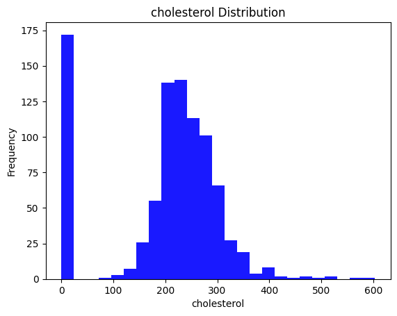

```python
#Cholesterol Distribution: A histogram showing the distribution of cholesterol levels in patients' blood. It helps identify cholesterol levels at high risk for heart disease.

plt.hist(df['chol'], bins=25, color='blue', alpha= 0.9)
plt.title('cholesterol Distribution')
plt.xlabel('cholesterol')
plt.ylabel('Frequency')
plt.show()
```

#### Resting Blood Pressure by Heart Disease:

**Click to review code**

```
#Resting Blood Pressure by Heart Disease: A box plot showing the distribution of resting blood pressure in patients based on whether they have heart disease. It helps understand the relationship between blood pressure and heart disease.

import seaborn as sns

# Example: assume 'trestbps' is resting blood pressure and 'target' indicates heart disease (0 = No, 1 = Yes)
# Create box plot
plt.figure(figsize=(8,6))
sns.boxplot(x='num', y='trestbps', data=df)
plt.xticks([0,1], ['No Heart Disease', 'Heart Disease'])
plt.xlabel('Heart Disease')
plt.ylabel('Resting Blood Pressure (mm Hg)')
plt.title('Resting Blood Pressure by Heart Disease')
plt.show()
```

[figure not shown]

```python
#Resting Blood Pressure by Heart Disease: A box plot showing the distribution of resting blood pressure in patients based on whether they have heart disease. It helps understand the relationship between blood pressure and heart disease.

import seaborn as sns

# Example: assume 'trestbps' is resting blood pressure and 'target' indicates heart disease (0 = No, 1 = Yes)
# Create box plot
plt.figure(figsize=(8,6))
sns.boxplot(x='num', y='trestbps', data=df)
plt.xticks([0,1], ['No Heart Disease', 'Heart Disease'])
plt.xlabel('Heart Disease')
plt.ylabel('Resting Blood Pressure (mm Hg)')
plt.title('Resting Blood Pressure by Heart Disease')
plt.show()
```

**Click to review code**

```
#Relationship Between Age and Maximum Heart Rate:
# A scatter plot showing the relationship between age and the maximum heart rate patients achieve.
# It helps see patterns or trends between these two features.


# Filter male and female thalach
y_male = df[df["sex"]== "Male"]["thalch"]
y_female = df[df["sex"]=="Female"]["thalch"]

# If you want to plot them on the same scatter plot with an index on x-axis
x_male = range(len(y_male))
x_female = range(len(y_female))

import matplotlib.pyplot as plt

plt.figure(figsize=(10,6))
plt.scatter(x_male, y_male, color='blue', label='Male')
plt.scatter(x_female, y_female, color='red', label='Female')
plt.xlabel('Index')
plt.ylabel('Maximum Heart Rate Achieved (thalach)')
plt.title('Maximum Heart Rate by Sex')
plt.legend()
plt.show()
```

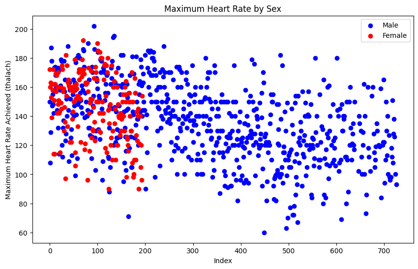

```python
#Relationship Between Age and Maximum Heart Rate:
# A scatter plot showing the relationship between age and the maximum heart rate patients achieve.
# It helps see patterns or trends between these two features.


# Filter male and female thalach
y_male = df[df["sex"]== "Male"]["thalch"]
y_female = df[df["sex"]=="Female"]["thalch"]

# If you want to plot them on the same scatter plot with an index on x-axis
x_male = range(len(y_male))
x_female = range(len(y_female))

import matplotlib.pyplot as plt

plt.figure(figsize=(10,6))
plt.scatter(x_male, y_male, color='blue', label='Male')
plt.scatter(x_female, y_female, color='red', label='Female')
plt.xlabel('Index')
plt.ylabel('Maximum Heart Rate Achieved (thalach)')
plt.title('Maximum Heart Rate by Sex')
plt.legend()
plt.show()
```

#### A Correlation Heatmap:

- was used to understand the relationship between all the features in the dataset.
- The correlation heatmap helps determine which features should be more closely examined or removed to improve model performance.

**Click to review code**

```
#plot correlation heatmap

# Select relevant columns
new_df = df[["age", "trestbps", "chol", "fbs", "thalch", "oldpeak", "num"]]

# Compute correlation matrix
corr_matrix = new_df.corr()  # note the parentheses

# Plot heatmap
plt.figure(figsize=(8,6))
sns.heatmap(corr_matrix, annot=True, cmap='coolwarm', fmt=".2f")
plt.title('Correlation Matrix of Selected Features')
plt.show()
```

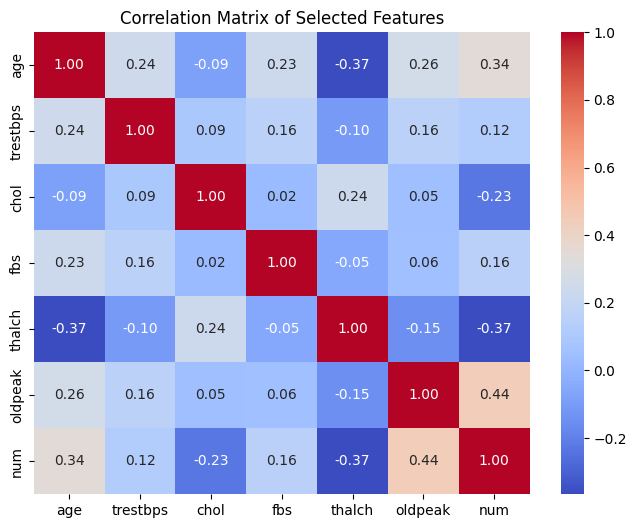

```python
#plot correlation heatmap

# Select relevant columns
new_df = df[["age", "trestbps", "chol", "fbs", "thalch", "oldpeak", "num"]]

# Compute correlation matrix
corr_matrix = new_df.corr()  # note the parentheses

# Plot heatmap
plt.figure(figsize=(8,6))
sns.heatmap(corr_matrix, annot=True, cmap='coolwarm', fmt=".2f")
plt.title('Correlation Matrix of Selected Features')
plt.show()
```

#### Removing Features

```python
# droping
df = df.drop("dataset", axis=1)
df = df.drop("id", axis=1)

df.head()
```

|  | age | sex | cp | trestbps | chol | fbs | restecg | thalch | exang | oldpeak | slope | ca | thal | num |
| --- | --- | --- | --- | --- | --- | --- | --- | --- | --- | --- | --- | --- | --- | --- |
| 0 | 63 | Male | typical angina | 145.0 | 233.0 | True | lv hypertrophy | 150.0 | False | 2.3 | downsloping | 0.0 | fixed defect | 0 |
| 1 | 67 | Male | asymptomatic | 160.0 | 286.0 | False | lv hypertrophy | 108.0 | True | 1.5 | flat | 3.0 | normal | 2 |
| 2 | 67 | Male | asymptomatic | 120.0 | 229.0 | False | lv hypertrophy | 129.0 | True | 2.6 | flat | 2.0 | reversable defect | 1 |
| 3 | 37 | Male | non-anginal | 130.0 | 250.0 | False | normal | 187.0 | False | 3.5 | downsloping | 0.0 | normal | 0 |
| 4 | 41 | Female | atypical angina | 130.0 | 204.0 | False | lv hypertrophy | 172.0 | False | 1.4 | upsloping | 0.0 | normal | 0 |

for more libraries for data visualization, visit: https://seaborn.pydata.org/examples/index.html

```python
#--------------------------------End of Data Visualization-----------------------------
```

## 2. Data Preprocessing

### 2.1 Handing missing values

Handling Missing Values: Ensuring no missing values in the dataset. If there are, the missing values will be filled using appropriate methods (e.g., mean or median).

```python
# Check for missing values
print("Missing values in each column:")
print(df.isnull().sum())

# Fill missing values
# For numerical columns, fill with mean or median
numerical_cols = df.select_dtypes(include=['int64', 'float64']).columns

for col in numerical_cols:
    if df[col].isnull().sum() > 0:
        df[col].fillna(df[col].mean(), inplace=True)  # or df[col].median()

# Verify no missing values remain
print("\nAfter filling missing values:")
print(df.isnull().sum())
```

```
Missing values in each column:
age           0
sex           0
cp            0
trestbps     59
chol         30
fbs          90
restecg       2
thalch       55
exang        55
oldpeak      62
slope       309
ca          611
thal        486
num           0
dtype: int64

After filling missing values:
age           0
sex           0
cp            0
trestbps      0
chol          0
fbs          90
restecg       2
thalch        0
exang        55
oldpeak       0
slope       309
ca            0
thal        486
num           0
dtype: int64
```

- **Remove and Solve missing values for categorycal Variable**

```python
# Remove and solve missing values for categorycal variable

# check the missing values again
# 1) quick diagnostics: show NaN counts per column
print("NaNs in X_train_norm per column:")
print(df.isnull().sum())
```

```
NaNs in X_train_norm per column:
age           0
sex           0
cp            0
trestbps      0
chol          0
fbs          90
restecg       2
thalch        0
exang        55
oldpeak       0
slope       309
ca            0
thal        486
num           0
dtype: int64
```

```python
# because of df["ca"] is missing alot, so it should be droped
df = df.drop("ca", axis=1)
#Drop any rows with missing data in the whole dataset
df_clean = df.dropna()
```

```python
# print out again to make sure all data is without missing any values.
df_clean.isnull().sum()
```

```
age         0
sex         0
cp          0
trestbps    0
chol        0
fbs         0
restecg     0
thalch      0
exang       0
oldpeak     0
slope       0
thal        0
num         0
dtype: int64
```

## 2.2 Converting Categorical Data to Numeric:

### 2.2.1 Encode Categorical-Features😊

Categorical columns such as sex (Sex), chest pain type (ChestPainType), resting ECG results (RestingECG), and others are converted to numeric format using label encoding.

```python
from sklearn.preprocessing import LabelEncoder

# Columns to encode
categorical_cols = ["sex", "cp", "fbs", "restecg", "exang", "slope", "thal"]

# Initialize LabelEncoder
le = LabelEncoder()

# Apply encoding
for col in categorical_cols:
    df_clean[col] = le.fit_transform(df_clean[col])

# Check the result
print(df_clean.head())
```

```
   age  sex  cp  trestbps   chol  fbs  restecg  thalch  exang  oldpeak  slope  \
0   63    1   3     145.0  233.0    1        0   150.0      0      2.3      0
1   67    1   0     160.0  286.0    0        0   108.0      1      1.5      1
2   67    1   0     120.0  229.0    0        0   129.0      1      2.6      1
3   37    1   2     130.0  250.0    0        1   187.0      0      3.5      0
4   41    0   1     130.0  204.0    0        0   172.0      0      1.4      2

   thal  num
0     0    0
1     1    2
2     2    1
3     1    0
4     1    0
```

[output not shown]

### 2.2.1 Encode Target😊

We perform binary classification using a dataset that originally contains five labels: 0 (no disease) and 1–4 (different levels of disease). To simplify the task, we convert the dataset into two classes: 0 (no disease) and 1 (disease, combining labels 1–4).

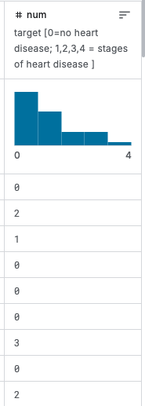

```python
# Convert to binary labels
# Original labels: 0 (no disease), 1–4 (disease levels)

df_clean['num'] = df_clean['num'].apply(lambda x: 0 if x == 0 else 1)
df_clean['target'] = df_clean['num']
df_clean.drop("num", axis=1)

# Check the result
print(df_clean['num'].value_counts())
print(df_clean.head())
```

```
num
1    201
0    171
Name: count, dtype: int64
   age  sex  cp  trestbps   chol  fbs  restecg  thalch  exang  oldpeak  slope  \
0   63    1   3     145.0  233.0    1        0   150.0      0      2.3      0
1   67    1   0     160.0  286.0    0        0   108.0      1      1.5      1
2   67    1   0     120.0  229.0    0        0   129.0      1      2.6      1
3   37    1   2     130.0  250.0    0        1   187.0      0      3.5      0
4   41    0   1     130.0  204.0    0        0   172.0      0      1.4      2

   thal  num  target
0     0    0       0
1     1    1       1
2     2    1       1
3     1    0       0
4     1    0       0
```

```python
# save data as csv file
# Save dataframe to CSV
df_clean.to_csv("heart_disease_binary.csv", index=False)
```

## 2.3 Data Splitting:

The dataset is split into training data (80%) and testing data (20%) to evaluate model performance. This split uses stratified sampling to balance the target class proportions between training and testing sets.

```python
from sklearn.model_selection import train_test_split

# Suppose X = features, y = target
X = df_clean.drop("target", axis=1)
y = df_clean["target"]

# Split dataset (80% train, 20% test)
X_train, X_test, y_train, y_test = train_test_split(X, y, test_size=0.2, random_state=42, stratify=y)

print("Train data: ", X_train.shape, "train  labels: ", y_train.shape)
print("Test data: ", X_test.shape, "test labels: ", y_test.shape)
```

```
Train data:  (297, 13) train  labels:  (297,)
Test data:  (75, 13) test labels:  (75,)
```

### 2.4 Standardization and Normalization:

For some feature selection methods, like Chi-Square, data needs to be normalized to the range [0, 1] using MinMaxScaler. For other algorithms, features are standardized using StandardScaler to ensure all features are on the same scale.

- MinMaxScaler (range [0,1]) for Chi-Square (chi2 requires non-negative inputs).
- StandardScaler (mean=0, std=1) for training ML models (SVM, KNN, LR benefit from scaling).

```python
from sklearn.preprocessing import MinMaxScaler, StandardScaler
from sklearn.feature_selection import chi2, mutual_info_classif, SelectKBest

# Fit MinMax on training set and transform both train and test (for chi2)
minmax = MinMaxScaler()
X_train_norm = pd.DataFrame(minmax.fit_transform(X_train), columns=X_train.columns, index=X_train.index)
X_test_norm  = pd.DataFrame(minmax.transform(X_test), columns=X_test.columns, index=X_test.index)

# Fit StandardScaler on training set and transform both train and test (for models)
std = StandardScaler()
X_train_std = pd.DataFrame(std.fit_transform(X_train), columns=X_train.columns, index=X_train.index)
X_test_std  = pd.DataFrame(std.transform(X_test), columns=X_test.columns, index=X_test.index)
```

## 3. Feature Selection

This study uses two different feature selection techniques:

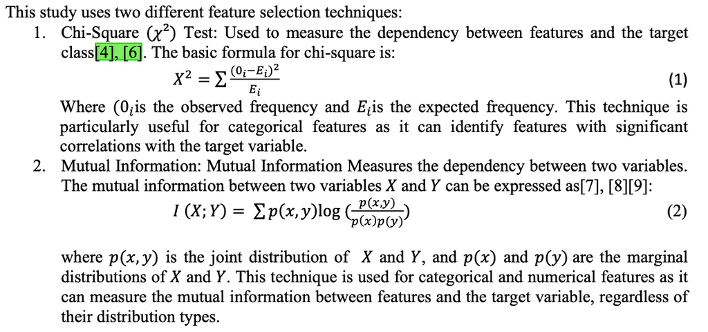

## 3.1 Chi-Square

**Chi-Square (χ²) test** is a statistical method commonly used in feature selection for machine learning, especially for **categorical data**.

### Key Points

**Purpose in Feature Selection:**

- Measure the **independence** between a feature and the target variable.
- Helps determine **how relevant a feature is** for predicting the target.

**How it works:**

- Compares the **observed frequency** of each category of a feature against the **expected frequency** if the feature and target were independent.
- The **Chi-Square statistic** is calculated as:

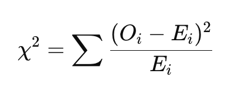

Where:

- (O_i) = observed frequency
- (E_i) = expected frequency

**Interpretation:**

- **High χ² value** → feature and target are dependent → feature is important.
- **Low χ² value** → feature and target are independent → feature may be irrelevant.

```python
k = 5  # top k features to select (change as desired)

# 5.1 Chi-Square (requires non-negative features -> use X_train_norm)
chi2_scores, chi2_pvals = chi2(X_train_norm, y_train)
chi2_df = pd.DataFrame({'feature': X_train_norm.columns, 'chi2_score': chi2_scores, 'p_value': chi2_pvals})
chi2_df = chi2_df.sort_values('chi2_score', ascending=False).reset_index(drop=True)
print("Chi-Square Scores:\n", chi2_df)

# Top-k by chi2
sel_chi2 = SelectKBest(score_func=chi2, k=k).fit(X_train_norm, y_train)
chi2_selected_features = X_train_norm.columns[sel_chi2.get_support()].tolist()
print(f"Top-{k} features by Chi-Square:", chi2_selected_features)
```

```
Chi-Square Scores:
      feature  chi2_score       p_value
0        num  137.000000  1.205851e-31
1      exang   33.730102  6.331335e-09
2         cp   26.350257  2.847810e-07
3        sex    6.585409  1.028180e-02
4       thal    4.671718  3.066324e-02
5      slope    4.523973  3.342313e-02
6     thalch    3.758994  5.252417e-02
7    oldpeak    2.382531  1.226986e-01
8       chol    1.493761  2.216338e-01
9        age    1.024653  3.114179e-01
10  trestbps    0.549799  4.583999e-01
11       fbs    0.241332  6.232456e-01
12   restecg    0.002472  9.603455e-01
Top-5 features by Chi-Square: ['sex', 'cp', 'exang', 'thal', 'num']
```

## 3.2 Multual Information

- It measures how much knowing the value of one variable reduces uncertainty about the other.
- It works for both categorical and continuous data, although for continuous data you often discretize it first.

**For two discrete variables X and 𝑌 mutual information is:**

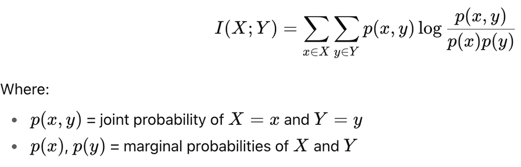

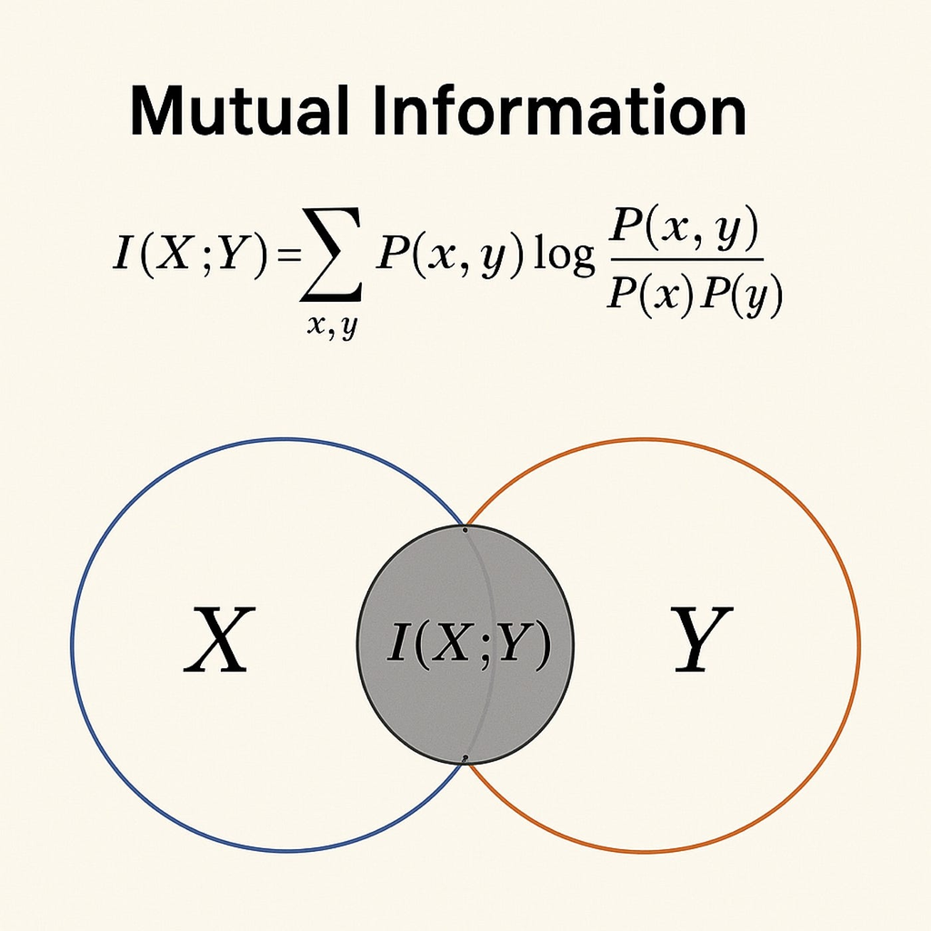

```python
# Mutual Information
mi_selector = SelectKBest(mutual_info_classif, k=5)
X_train_mi = mi_selector.fit_transform(X_train, y_train)
X_test_mi = mi_selector.transform(X_test)
```

# 4. Train and Evalute Four Machine Learning Models

- There are four models are eperimented with such as Random Forest, Support Vector Machine (SVM),  
  Logistic Regression, and K-Nearest Neighbors (KNN).
- The purpose of experiment with multiple models to access the performane model.
- Here is the parameters set up for each models:

[output not shown]

```python
# Import libraries
from sklearn.linear_model import LogisticRegression # library for LogisticRegrssion
from sklearn.ensemble import RandomForestClassifier
from sklearn.svm import SVC
from sklearn.neighbors import KNeighborsClassifier
from sklearn.metrics import accuracy_score, confusion_matrix, classification_report # for calculate model's performances

# ---------------------------
# 5. Define Models (with tuned parameters)
# ---------------------------
models = {
    "Logistic Regression": LogisticRegression(
        solver="liblinear", C=1.0, max_iter=1000, random_state=42
    ),
    "Random Forest": RandomForestClassifier(
        n_estimators=200, max_depth=10, random_state=42
    ),
    "SVM": SVC(
        kernel="rbf", C=1.0, gamma="scale", probability=True, random_state=42
    ),
    "KNN": KNeighborsClassifier(
        n_neighbors=7, metric="minkowski", p=2
    )
}

#--------------Function for training models------------------
def run_experiment(X_train, X_test, y_train, y_test, title):
    print(f"\n===============================")
    print(f"   {title}")
    print(f"===============================")

    # Standardize for fairness (except Chi-square which needs MinMax before feature selection)
    scaler = StandardScaler()
    X_train_scaled = scaler.fit_transform(X_train)
    X_test_scaled = scaler.transform(X_test)

    for name, model in models.items():
        print(f"\n--- {name} ---")
        model.fit(X_train_scaled, y_train)
        y_pred = model.predict(X_test_scaled)

        print("Accuracy:", accuracy_score(y_test, y_pred))
        print("Confusion Matrix:\n", confusion_matrix(y_test, y_pred))
        print("Classification Report:\n", classification_report(y_test, y_pred))

        # plot confusion matrix
        plot_confusion_matrix(y_test, y_pred, model_name=name)

#---------------------Function for ploting confusion matrixs---------------------
import seaborn as sns
from sklearn.metrics import confusion_matrix

def plot_confusion_matrix(y_true, y_pred, model_name="Model"):
    cm = confusion_matrix(y_true, y_pred)
    plt.figure(figsize=(6, 4))
    sns.heatmap(cm, annot=True, fmt="d", cmap="Blues", cbar=False)
    plt.title(f"Confusion Matrix - {model_name}")
    plt.xlabel("Predicted Label")
    plt.ylabel("True Label")
    plt.show()
```

## 4.1 Experiment 1: Without Feature Selection

```
===============================
   Experiment 1: Without Feature Selection
===============================

--- Logistic Regression ---
Accuracy: 1.0
Confusion Matrix:
 [[34  0]
 [ 0 41]]
Classification Report:
               precision    recall  f1-score   support

           0       1.00      1.00      1.00        34
           1       1.00      1.00      1.00        41

    accuracy                           1.00        75
   macro avg       1.00      1.00      1.00        75
weighted avg       1.00      1.00      1.00        75
```

```
--- Random Forest ---
Accuracy: 1.0
Confusion Matrix:
 [[34  0]
 [ 0 41]]
Classification Report:
               precision    recall  f1-score   support

           0       1.00      1.00      1.00        34
           1       1.00      1.00      1.00        41

    accuracy                           1.00        75
   macro avg       1.00      1.00      1.00        75
weighted avg       1.00      1.00      1.00        75
```

```
--- SVM ---
Accuracy: 1.0
Confusion Matrix:
 [[34  0]
 [ 0 41]]
Classification Report:
               precision    recall  f1-score   support

           0       1.00      1.00      1.00        34
           1       1.00      1.00      1.00        41

    accuracy                           1.00        75
   macro avg       1.00      1.00      1.00        75
weighted avg       1.00      1.00      1.00        75
```

```
--- KNN ---
Accuracy: 0.9733333333333334
Confusion Matrix:
 [[33  1]
 [ 1 40]]
Classification Report:
               precision    recall  f1-score   support

           0       0.97      0.97      0.97        34
           1       0.98      0.98      0.98        41

    accuracy                           0.97        75
   macro avg       0.97      0.97      0.97        75
weighted avg       0.97      0.97      0.97        75
```

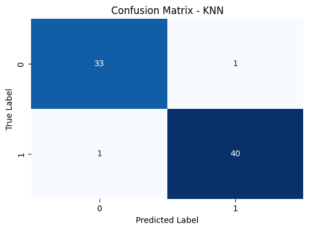

```python
# -----------------------------------------
# Experiment 1: Without Feature Selection
# -----------------------------------------
run_experiment(X_train, X_test, y_train, y_test, "Experiment 1: Without Feature Selection")
```

[output not shown]